[figure not shown]

# Python Group Assignment

## Group Member:

### Wang Chen, Liu Jiayu, Li Zhengze, Zhang Jian

# PART A: What's Our Model?

#### Where:

- R_it is the total return of a stock or portfolio, i at time t;
- R_ft is the risk free rate of return at time t;
- R_Mt is the total market portfolio return at time t;
- R_it - Rft is expected excess return;
- R_Mt - Rft is the excess return on the market portfolio (index);
- SMB_t is the size premium (small minus big); and
- HML_t is the value premium (high minus low).
- β_1,2,3 refer to the factor coefficients.

## Our Model

- For our Three-Factor Model, we change the third factor into the ln(Volume_it).
- The new formula is shown as belowed:

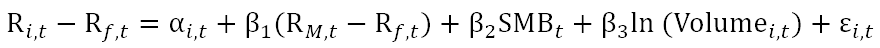

#### Note that,

- ln(Volume_it) is the third factor, measuring the trading activity;

## Why Volume?

#### For the Trading Activity:

- Volume is the number of shares or contracts traded in a security or an entire market during a given period of time.
- It's an important indicator to measure the relative worth of a market move. If the markets make a strong price movement, then the strength of that movement depends on the volume for that period. The higher the volume during the price move, the more significant the move.
- We except this variable can measure how active the stock is traded and contribute to our model as the third factor.

# PART B: What's the Variable?

## Variable Selection

We still need to select the other 4 variables, which contains:

- R, the research portfolio;
- R_f, the risk free rate of return;
- R_M, the total market portfolio return;
- SMB, the size premium (small minus big);

## Variable Selection

#### For the total market portfolio return:

- As the stock market has been limited in US, S&P 500 Index is chosen as the market variable.

## Variable Selection

#### For the research portfolio:

- Stocks:
  - Stocks selected are the conponent companies of S&P 500;
  - There are 505 stocks listed.
- Portfolio:
  - We create a portfolios of energy industry, which is supposed to be the traditional and foundamental industry, and;
  - As a comparison, a portfolios of technology industry is selected to represent the most creative industry;
  - The two lists are shown as below:

    ```
    energy_list = ['XOM','CVX','COP','KMI','SLB','PSX','EOG','OXY','VLO','MPC','OKE','WMB','BHGE','PXD','HES']
    technology_list = ['MSFT','AAPL','GOOG','GOOGL','FB','INTC','CSCO','ORCL','ADBE','CRM','ACN','IBM','TXN','AVGO','NVDA']
    ```

## For Instance: Stock MSFT(Microsoft)

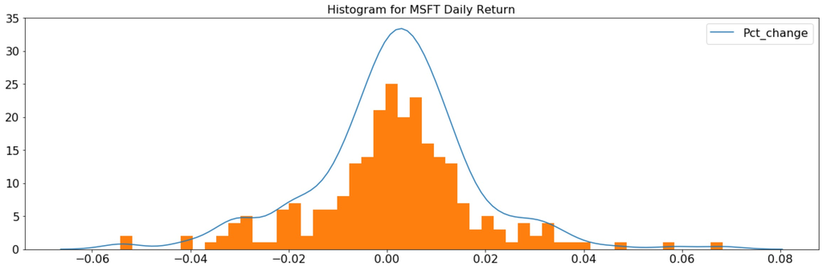

## Return of the Two Industry

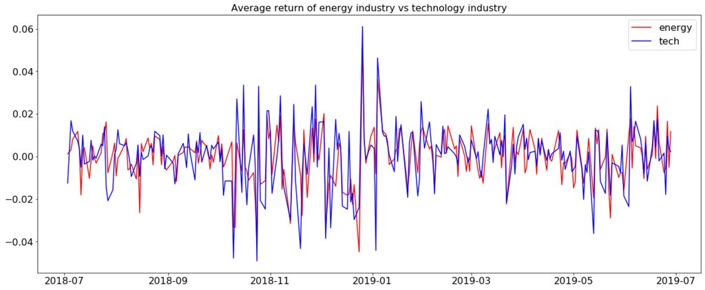

## Variable Selection

#### For the risk free rate of return:

- The 1-month Treasury Bill rate is selected to represent the risk free rate.
- Note that The 1-month Treasury Bill rate measures the return rate of one year.

## Variable Selection

#### For the size premium (small minus big):

- This variable is constructed basen on the market cap to represent the effect of market cap.
- We notice that the individual market weights level of each component stocks of the S&P 500 have already been calculated based on their market cap to construct the index, so it's obvious that Market Weight Level of Stock_i is proportional to its Market Cap:

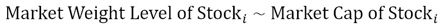

### So it's convenient for us to use the individual market weights of each component stocks to divide them into 'Big' and 'Small' group and label them.

# PART C: How We Make It?

## Step 1. Scrap Data

- Defined a fuction named 'dataScraping' to scrap the stock data from Yahoo Finance and a piece of code to get the 1-mon treasury return data and market index data, then save it.
- Note that:
  - Subject to the website, we can only get 100 days of data step by step;
  - The last row is supposed to be excluded;
  - Subject to the unstable Internet, we should only get 50 stocks data or may lead to unexpected error.

```python
# function to scrap the stock data
def dataScraping(data_list, start_date, end_date):
    yahoo_finance_url = 'https://au.finance.yahoo.com/quote/%s/history?period1=%s&period2=%s&interval=1d&filter=history&frequency=1d'
    df_list = []
    count = 0
    one_hundred_epoch = 60 * 60 * 24 * 100      # used to get 100 days of data step by step
    for data in data_list:
        print("Scraping", data, "...")
        # try to get web page if end_date > start_date
        first_round = True
        temp_date   = end_date
        while temp_date > start_date:
            yahoo_hist_price_page = rq.get(yahoo_finance_url % (data, start_date, temp_date))
            if yahoo_hist_price_page.status_code == 200:
                if first_round:
                    # exclude last row
                    df_list.append(pd.read_html(yahoo_hist_price_page.text)[0].iloc[:-1])
                    first_round = False
                else:
                    df_combined = pd.read_html(yahoo_hist_price_page.text)[0].iloc[:-1]
                    # more efficient way to combine
                    df_list[count] = pd.concat([df_list[count], df_combined], axis=0)

            else:
                raise Exception('Some Error Happened. Http Error Code %d' % yahoo_hist_price_page.status_code)
            temp_date = str(int(temp_date) - one_hundred_epoch)
        count += 1
    print("----------------------\nScraping process done!")
    return df_list
```

```python
# Scraping market index data

security_list   = result                      # Security list
market_index_list = ['%5EGSPC']               # Market index list
start_date = dateToEpoch('2018-07-01')
end_date   = dateToEpoch('2019-06-30')

# data from yahoo finance, stocks and market index
stocks_df = dataScraping(security_list, start_date, end_date)
market_index_df = dataScraping(market_index_list, start_date, end_date)
```

```python
# data from daily treasury
years = ['2018', '2019']
treasury_url = 'https://www.treasury.gov/resource-center/data-chart-center/interest-rates/Pages/TextView.aspx?data=billRatesYear&year=%s'
first_bool = True
for year in years:
    treasury_page = rq.get(treasury_url % year)
    if treasury_page.status_code == 200:
        bill_rate_df = pd.read_html(treasury_page.text)[1]
    else:
        raise Exception('Some Error Happened. Http Error Code %d' % treasury_page.status_code)
    if first_bool:
        bill_rate_month_df = pd.DataFrame()
        bill_rate_month_df['Date'] = bill_rate_df['Unnamed: 0_level_0']['DATE']
        bill_rate_month_df['Month Rate'] = bill_rate_df['4 WEEKS']['BANK DISCOUNT']
        # convert time to datetime
        bill_rate_month_df['Date'] = pd.to_datetime(bill_rate_month_df['Date'])
    else:
        new_month_df = pd.DataFrame()
        new_month_df['Date'] = bill_rate_df['Unnamed: 0_level_0']['DATE']
        new_month_df['Month Rate'] = bill_rate_df['4 WEEKS']['BANK DISCOUNT']
        # convert time to datetime
        new_month_df['Date'] = pd.to_datetime(new_month_df['Date'])
        # concat two dataframe
        bill_rate_month_df = pd.concat([bill_rate_month_df, new_month_df], axis = 0)
    first_bool = False
bill_rate_month_df.head()
```

```python
# Saving Data to csv

bill_rate_month_df.to_csv('bill_rate.csv', index=False)
market_index_df[0].to_csv('market_index.csv', index=False)
for i in range(len(stocks_df)):
    stocks_df[i].to_csv('./data/stocks' + str(i) + '.csv')
for i in range(len(market_index_df)):
    market_index_df[i].to_csv('./data/market' + str(i) + '.csv')
```

## Step 2. Data Cleaning

- Loading Data from csv saved before;
- Defined a fuction named 'dateToEpoch' to change the date format;
- Defined a fuction named 'dataCleaning' to clean data, which contains:
  - Change numeric str to numeric values
  - Drop duplicated data
  - Add security name as a column
  - Convert time format
  - Merge risk-free rate by Date
  - Reverse dataframe
- Check if there is any value lost;
- Classify all the stocks into "Big" and "Small".

```python
# Loading Data from csv saved before

# Load stocks data from 2018/7/1 to 2019/6/30
stocks_df = []
for i in range(len(security_list)):
    stocks_df.append(pd.read_csv('./data/stocks' + str(i) + '.csv').drop(['Unnamed: 0'],axis=1))

# Load market index
market_index_df = []
for i in range(len(market_index_list)):
    market_index_df.append(pd.read_csv('market_index.csv'))
# Load bill rate
bill_rate_month_df = pd.read_csv('bill_rate.csv')
bill_rate_month_df['Date'] = pd.to_datetime(bill_rate_month_df['Date'])
```

```python
# Function: change format date into epoch time
def dateToEpoch(date):
    time_tuple = time.strptime(date, '%Y-%m-%d')
    time_epoch = time.mktime(time_tuple)
    time_tostr = str(int(time_epoch))

    return time_tostr
```

```python
# Function: used to cleaning data
def dataCleaning(df_list, data_list):
    for i in range(len(df_list)):
        for column in df_list[i].columns:
            if column == 'Date':
                continue
            df_list[i][column] = pd.to_numeric(df_list[i][column], errors='coerce')
        # Drop duplicated data
        df_list[i].drop_duplicates(["Date"], keep="first", inplace=True)
        # Add security name as a column
        df_list[i]['Name'] = str(data_list[i])
        # Convert time format
        df_list[i]['Date'] = pd.to_datetime(df_list[i]['Date'])
        # Merge risk-free rate by Date
        df_list[i] = pd.merge(df_list[i], bill_rate_month_df, how='inner', on=['Date'])
        # Reverse dataframe
        df_list[i] = df_list[i][::-1]
        # Reset index
        df_list[i] = df_list[i].reset_index(drop=True)
```

```python
# Featuring factor of Rs - Rm

mid = len(stocks_df) // 2

big_merge_df   = stocks_df[0][['Date', 'Pct_change']]
small_merge_df = stocks_df[mid][['Date', 'Pct_change']]
for i in range(1, mid):
    big_merge_df = pd.merge(big_merge_df, stocks_df[i][['Date', 'Pct_change']], how='outer', on=['Date'])
for i in range(mid+1, len(stocks_df)):
    small_merge_df = pd.merge(small_merge_df, stocks_df[i][['Date', 'Pct_change']], how='outer', on=['Date'])
```

```python
# Feature Engineering

for i in range(len(market_index_df)):
    market_index_df[i]['Pct_change'] = market_index_df[i]['Adj. close**'].pct_change(periods = 1)
    market_index_df[i]['Rm - Rf'] = market_index_df[i]['Pct_change'] - stocks_df[0]['Month Rate'].shift() / 100 / 365

for i in range(len(stocks_df)):

    # Ri of stocks
    stocks_df[i]['Pct_change'] = stocks_df[i]['Adj. close**'].pct_change(periods = 1)
    # Ri - Rf of stocks
    stocks_df[i]['Ri - Rf'] = stocks_df[i]['Pct_change'] - stocks_df[0]['Month Rate'].shift() / 100 / 365
    # Log volume
    stocks_df[i]['Log_Volume'] = np.log(stocks_df[i]['Volume'])

    # Rmkt - Rf from market_index, used sp500
    stocks_df[i] = pd.merge(stocks_df[i], market_index_df[0][['Date', 'Rm - Rf']], how='inner', on=['Date'])
```

## Step 3. Data Pre-process

#### We should get the following variables for each time t and stock i, and then merge and save them:

- Get 'Ri - Rf'
- Get 'Rm - Rf'
- Get 'Rs - Rb'
- Get 'Log_Volume'

#### Note that:

- There are another two portfolios (classified as Ri) which contains energy and technology industry, and the two lists are shown as below:

  ```
  energy_list = ['XOM','CVX','COP','KMI','SLB','PSX','EOG','OXY','VLO','MPC','OKE','WMB','BHGE','PXD','HES']
  tech_list   = ['MSFT','AAPL','GOOG','GOOGL','FB','INTC','CSCO','ORCL','ADBE','CRM','ACN','IBM','TXN','AVGO','NVDA']
  ```

- 1-month treasury rate should be divided by 100, for real percentage, and 365, for a single day, to get Rf.
- We should log the variable Volume to make it reasonable.
- We also standardised all the variables to do the regression.

## Step 4. Do the regression

#### Then think how to explain the result.

```python
# Do the regression and save information
score_list = []
name_list  = []
F1_list = []
F2_list = []
F3_list = []
P_F1_list = []
P_F2_list = []
P_F3_list = []
factor_list = ['Rm - Rf', 'Rs - Rb', 'Log_Volume']
for stock in stocks_df:
    # drop rows contain nan
    stock.dropna(axis=0, inplace=True)
    X_train = stock[factor_list]
    Y_train = stock['Ri - Rf']
    if stock.shape[0] <= 0:
        continue
    # data standardised
    scaler = StandardScaler()
    for factor in factor_list:
        X_train[factor] = scaler.fit_transform(X_train[factor].values.reshape(-1,1))
    Y_train = scaler.fit_transform(Y_train.values.reshape(-1,1))
    # fit linear regression model
    reg = LinearRegression(normalize=True, n_jobs=4).fit(X_train, Y_train)
    # Save information
    score_list.append(reg.score(X_train, Y_train))
    name_list.append(stock['Name'][-1:].values[0])
    F1_list.append(reg.coef_[0, 0])
    F2_list.append(reg.coef_[0, 1])
    F3_list.append(reg.coef_[0, 2])
    P_F1_list.append(reg.p[0, 0])
    P_F2_list.append(reg.p[0, 1])
    P_F3_list.append(reg.p[0, 2])
```

# PART D: How to Explain?

## Regression Result

#### Regression in two different industries: energy and technology

- Stocks of energy companies: XOM, CVX, COP, KMI, SLB, PSX, EOG, OXY, VLO, MPC, OKE, WMB, BHGE, PXD, HES
- Stocks of technology companies: MSF, AAPL, GOOG, GOOGL, FB, INTC, CSCO, ORCL, ADBE, CRM, ACN, IBM, TXN, AVGO, NVDA

## Regression Result

#### Regression of energy industry

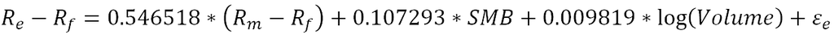

#### Note that, average R²= 0.382073

#### Regression of technology industry

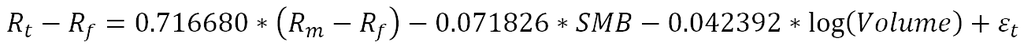

#### Note that, average R²=0.523144

## For Instance: Stock MSFT(Microsoft)

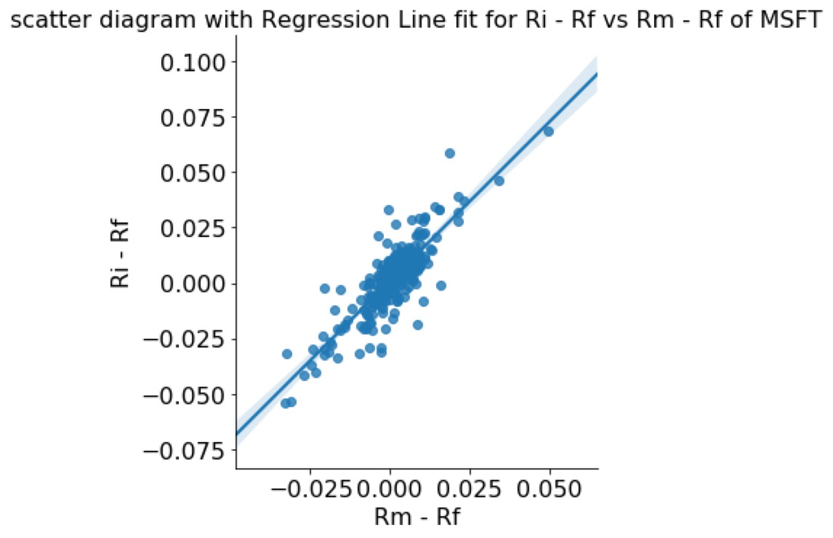

## Conclusion 3

- Average R² of energy industry = 0.382073
- Average R² of technology industry = 0.523144
- Average R² of energy industry = 0.382073 < Average R² of technology industry = 0.523144， which shows that Market Risk Premium (X1: Rm-Rf), Market Cap factor (X2: SMB) and Volume factor (X3: ln(Volume)) have more explanations for the excess return of stocks in technology industry than for the excess return of stocks in energy industry；

## Conclusion 4

- average β_2 of energy industry = 0.107293 > 0;
- average β_3 of energy industry = 0.009819 > 0;
- average β_2 of technology = -0.071826 < 0;
- average β_3 of technology = -0.042392 < 0;
- So Market Cap factor (X_2: SMB) and Volume factor (X_3: log(Volume)) have positive impacts on the excess return of stocks in energy industry, however, these two factors have negative impacts on the excess return of stocks in technology industry.